# sorting

Simon Rayner

2022-11-20

## Introduction

The next thing we want to look at is code efficiency. If you are working with a small dataset, then you won’t have a problem with this. But if, for example, you are working with NGS datasets then the efficiency of the code (for example in terms of CPU usage or memory requirements) can be an issue.

To look at this, we will consider a simple example of sorting a simple array of 10 numbers.

Although sorting numbers is a trivial task, there are many different ways to do it …

## Bubble Sort

In a bubble sort, in each pairwise comparison, the larger element is moved towards the end of the array. then the process is repeated for the next largest.

```r
# function to sort the array using bubble sort
bubble_sort <- function(x)
{
    # calculate the length of array
    n <- length(x)
             # run loop n-1 times
        for (i in 1 : (n - 1)) {
              # run loop (n-i) times
            for (j in 1 : (n - i)) {
                  # compare elements
                if (x[j] > x[j + 1]) {
                    temp <- x[j]
                      x[j] <- x[j + 1]
                      x[j + 1] <- temp
                }
            }
        }
      x
}

# take 10 random numbers between 1 - 100
set.seed(13)
arr <- sample(1 : 100, 10)

# sort the array and store the result
# in sorted_array
sorted_array <- bubble_sort(arr)

# print sorted_array
sorted_array
```

```
##  [1]  3  4  6 22 48 64 74 77 88 98
```

## Selection Sort

This algorithm is commonly used in the R language. In this approach, the smallest element from the unsorted list is pushed to the start of the list in each iteration

```r
# function to sort array using selection sort
selection_sort <- function(x)
{
      # length of array
    n <- length(x)
      for (i in 1 : (n - 1))
    {
          # assume element at i is minimum
        min_index <- i
          for (j in (i + 1) : (n))
        {
              # check if element at j is smaller
              # than element at min_index
            if (x[j] < x[min_index]) {
                  # if yes, update min_index
                min_index = j
            }
        }
          # swap element at i with element at min_index
        temp <- x[i]
          x[i] <- x[min_index]
          x[min_index] <- temp
    }
    x
}

# take sample input
set.seed(13)
arr <- sample(1 : 100, 10)

# sort array
sorted_arr <- selection_sort(arr)

# print array
sorted_arr
```

```
##  [1]  3  4  6 22 48 64 74 77 88 98
```

## Quick Sort

This uses a divide and conquers algorithm in which a random element is selected as a pivot and the array is partitioned around this point.

```r
# function to sort the values
quickSort <- function(arr) {

  # Pick a number at random
  random_index <- sample(seq_along(arr), 1);
  pivot <- arr[random_index]
  arr <- arr[-random_index]

  # Create array for left and right values.
  left <- c()
  right <- c()

  # Move all smaller and equal values to the
  # left and bigger values to the right.
  # compare element with pivot
  left<-arr[which(arr <= pivot)]
  right<-arr[which(arr > pivot)]

  if (length(left) > 1)
  {
    left <- quickSort(left)
  }
  if (length(right) > 1)
  {
    right <- quickSort(right)
  }

  # Return the sorted values.
  return(c(left, pivot, right))
}

# take sample array
set.seed(13)
arr <- sample(1:100, 10)

# call quickSort function
result <- quickSort(arr)

# print result
result
```

```
##  [1]  3  4  6 22 48 64 74 77 88 98
```

## Speed Test

What we are interested is whether one particular sort algorithm is faster than the others. To test this, we can use the `microbenchmark` package. This simply involves wrapping a `microbenchmark` instance around a call to these three functions.

```r
library(microbenchmark)
library(ggplot2)

mbmR<- microbenchmark(
  quickSort(arr),selection_sort(arr),bubble_sort(arr)
)

mbmR
```

```
## Unit: microseconds
##                 expr    min      lq     mean  median      uq     max neval
##       quickSort(arr) 62.146 74.9050 81.81938 77.3690 88.1835 139.727   100
##  selection_sort(arr)  6.008  6.2365  6.56378  6.4215  6.8105   9.751   100
##     bubble_sort(arr)  9.192  9.5150  9.87647  9.7895 10.0625  15.572   100
```

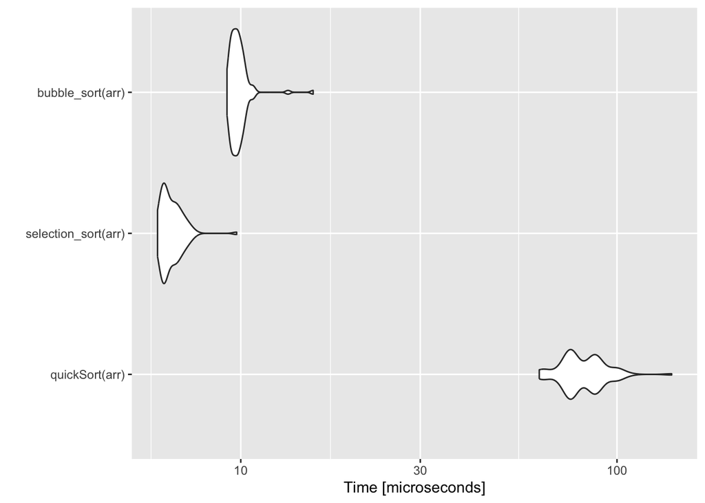

```r
autoplot(mbmR, fill = "#FFDB6D", color = "#C4961A")
```

The results indicate that `bubbleSort` and `selectionSort` are notably faster than `quickSort`.

However, we were only sorting 10 numbers. So let’s see what happens when we increase the array size…

## Speed Test 2

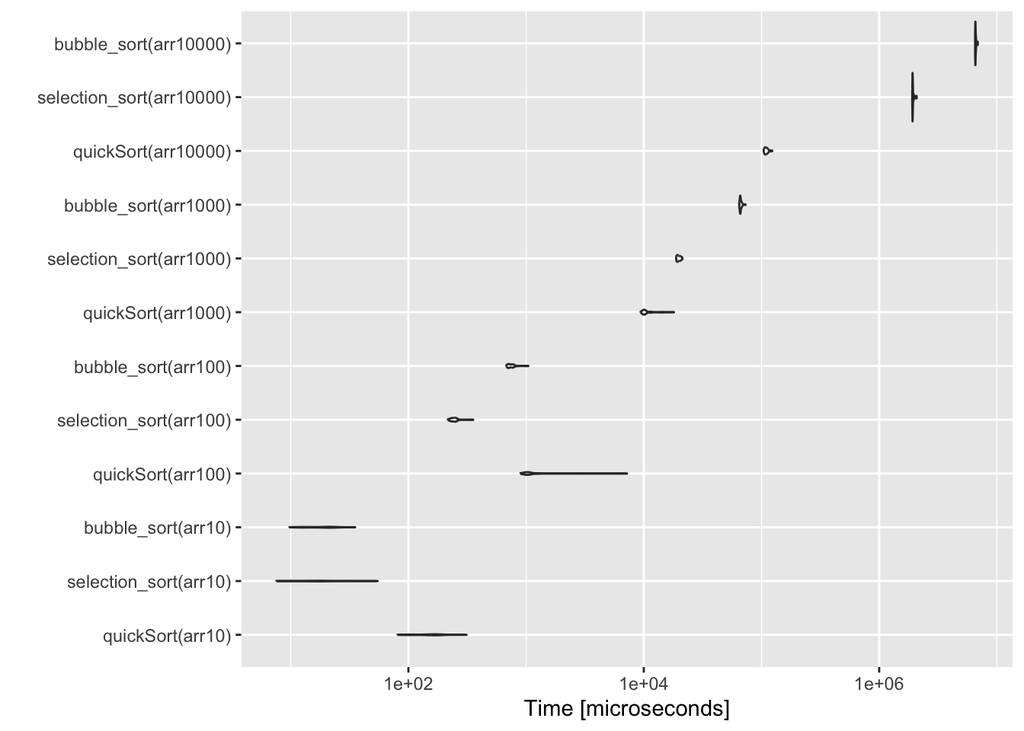

```r
set.seed(13)
arr10 <- sample(1:10, 10)
arr100 = sample(1:100, 100)
arr1000 = sample(1:1000, 1000)
arr10000 = sample(1:10000, 10000)
#arr100000 = sample(1:100000, 100000)


mbmR<- microbenchmark(
  quickSort(arr10),selection_sort(arr10),bubble_sort(arr10),
  quickSort(arr100),selection_sort(arr100),bubble_sort(arr100),
  quickSort(arr1000),selection_sort(arr1000),bubble_sort(arr1000),
  quickSort(arr10000),selection_sort(arr10000),bubble_sort(arr10000),
  times=50
)

autoplot(mbmR, fill = "#FFDB6D", color = "#C4961A")
```

what we see is that for larger datasets, `quickSort` turns out to be much faster and `bubbleSort` becomes the worst.

```r
mbmR
```

```
## Unit: microseconds
##                      expr         min          lq         mean       median
##          quickSort(arr10)      80.701     107.770 1.483662e+02     153.7115
##     selection_sort(arr10)       7.538      10.584 1.737184e+01      16.1360
##        bubble_sort(arr10)       9.710      13.774 1.850000e+01      19.5135
##         quickSort(arr100)     895.828     985.846 1.203362e+03    1043.0620
##    selection_sort(arr100)     215.975     232.286 2.456304e+02     243.4545
##       bubble_sort(arr100)     679.939     707.524 7.568058e+02     736.8075
##        quickSort(arr1000)    9392.102    9895.329 1.074434e+04   10198.0195
##   selection_sort(arr1000)   18844.530   19227.186 1.982334e+04   19677.6640
##      bubble_sort(arr1000)   64725.282   65675.169 6.656809e+04   66234.9360
##       quickSort(arr10000)  104420.067  107345.038 1.103411e+05  109762.3900
##  selection_sort(arr10000) 1909812.369 1919388.051 1.937822e+06 1926488.5700
##     bubble_sort(arr10000) 6534499.106 6562000.665 6.609473e+06 6578235.9555
##           uq         max neval
##      174.163     312.055    50
##       18.836      54.787    50
##       22.010      35.298    50
##     1113.783    7208.082    50
##      253.262     355.448    50
##      774.955    1045.229    50
##    10801.643   18044.143    50
##    20348.521   21265.133    50
##    67277.508   73116.562    50
##   112375.510  123474.870    50
##  1934180.027 2081493.191    50
##  6630612.786 6884205.817    50
```

```r
library(readr)
write_csv(mbmR, sort1000BenchmarkFilePath)
```

## Running the same test as an Rscript.

The same code is also written as a stripped down R script. If we run

```
(base) MacBook-Pro-2:sorting simonray$ Rscript sorting.R
```

```
Unit: microseconds
                     expr         min          lq         mean       median
         quickSort(arr10)      38.149      53.450 2.824769e+02      70.9450
    selection_sort(arr10)       5.331       7.363 1.059576e+01      10.0160
       bubble_sort(arr10)       7.764       9.900 4.995191e+02      12.6210
        quickSort(arr100)     417.028     462.718 5.350693e+02     493.9365
   selection_sort(arr100)     193.490     206.621 2.226355e+02     213.6505
      bubble_sort(arr100)     535.154     551.968 5.960996e+02     570.2805
       quickSort(arr1000)    4300.775    4654.138 5.759737e+03    5481.1080
  selection_sort(arr1000)   17680.543   18297.230 1.966044e+04   18777.0030
     bubble_sort(arr1000)   49083.473   50898.149 5.419740e+04   51884.3140
      quickSort(arr10000)   48699.775   54391.015 5.848513e+04   58777.8955
 selection_sort(arr10000) 1779345.775 1827740.182 1.891493e+06 1853403.3895
    bubble_sort(arr10000) 5023551.453 5174123.375 5.377712e+06 5229302.8760
          uq         max neval
      88.851    8978.487    50
      13.476      26.046    50
      16.477   24332.503    50
     542.982    1853.590    50
     240.480     292.342    50
     644.183     733.910    50
    6323.116   11471.952    50
   21222.229   27507.611    50
   55246.240   74821.560    50
   60776.604  100010.980    50
 1942285.756 2150945.887    50
 5552191.936 7057834.666    50
```